# TP3

projet Statistique sous R et Python

Omar THIAM

2024-05-02

Introduction Le but principal de ce travail pratique est de recréer fidèlement les graphiques fournis. Pour ce faire, nous débuterons par l’importation des données. Ensuite, nous procéderons à la préparation de ces données en accomplissant les tâches suivantes :

1. Modification du format de la base de données.
2. Ajout d’une variable dénommée “Western Africa” ainsi qu’une variable “World”. Ces variables seront stockées dans deux cadres de données distincts. Par la suite, nous fusionnerons ces cadres pour en former un seul.
3. Ce processus sera répété pour chaque graphe requis. En conclusion, nous réaliserons une représentation graphique en utilisant le cadre de données final.

# 1 Importations des Bibliothèques

```r
library(haven)
library(tidyverse)
library(here)
library(readxl)
library(dplyr)
library(ggplot2)
library(janitor)
library(plotly)
# library(here)
# library(labelled)
# library(gtsummary)
```

# 2 Importation et inspection de la base

```r
projet_3 <- here::here()
PGA <- paste0(projet_3,"/population-growth-annual.csv")
PGA <- read_csv(PGA)
head(PGA)
```

```
## # A tibble: 6 × 8
##   `Region Name` `Region Alpha-3 Code` `Region Alpha-2 Code` `Start Year`
##   <chr>         <chr>                 <chr>                        <dbl>
## 1 Afghanistan   AFG                   AF                            1961
## 2 Afghanistan   AFG                   AF                            1962
## 3 Afghanistan   AFG                   AF                            1963
## 4 Afghanistan   AFG                   AF                            1964
## 5 Afghanistan   AFG                   AF                            1965
## 6 Afghanistan   AFG                   AF                            1966
## # ℹ 4 more variables: `End Year` <dbl>, Value <dbl>, Unit <chr>, Source <chr>
```

```r
projet_3 <- here::here()
GII<- paste0(projet_3,"/gender-inequality-index.csv")
GII <- read_csv(GII)
head(GII)
```

```
## # A tibble: 6 × 8
##   `Region Name` `Region Alpha-3 Code` `Region Alpha-2 Code` `Start Year`
##   <chr>         <chr>                 <chr>                        <dbl>
## 1 Afghanistan   AFG                   AF                            2005
## 2 Afghanistan   AFG                   AF                            2006
## 3 Afghanistan   AFG                   AF                            2007
## 4 Afghanistan   AFG                   AF                            2008
## 5 Afghanistan   AFG                   AF                            2009
## 6 Afghanistan   AFG                   AF                            2010
## # ℹ 4 more variables: `End Year` <dbl>, Value <dbl>, Unit <lgl>, Source <chr>
```

```r
projet_3 <- here::here()
AGGPC <- paste0(projet_3,"/annual-growth-in-gni-per-capita.csv")
AGGPC <- read_csv(AGGPC)
head(AGGPC)
```

```
## # A tibble: 6 × 8
##   `Region Name` `Region Alpha-3 Code` `Region Alpha-2 Code` `Start Year`
##   <chr>         <chr>                 <chr>                        <dbl>
## 1 Albania       ALB                   AL                            1998
## 2 Albania       ALB                   AL                            1999
## 3 Albania       ALB                   AL                            2000
## 4 Albania       ALB                   AL                            2001
## 5 Albania       ALB                   AL                            2002
## 6 Albania       ALB                   AL                            2003
## # ℹ 4 more variables: `End Year` <dbl>, Value <dbl>, Unit <chr>, Source <chr>
```

Pour connaitre la dimension des bases3, il est possible d’utilisé les fonctions comme **dim** ou **str**.

```r
dim(PGA) # 13070 observations et 8 variables
```

```
## [1] 13070     8
```

```r
dim(GII) # 4889 observations et 8 variables
```

```
## [1] 4889    8
```

```r
dim(AGGPC) # 5404 observations et 8 variables
```

```
## [1] 5404    8
```

**NB** : la fonction *str* donne les caractéristiques générales de la base (des variables).

```r
str(PGA)
```

```
## spc_tbl_ [13,070 × 8] (S3: spec_tbl_df/tbl_df/tbl/data.frame)
##  $ Region Name        : chr [1:13070] "Afghanistan" "Afghanistan" "Afghanistan" "Afghanistan" ...
##  $ Region Alpha-3 Code: chr [1:13070] "AFG" "AFG" "AFG" "AFG" ...
##  $ Region Alpha-2 Code: chr [1:13070] "AF" "AF" "AF" "AF" ...
##  $ Start Year         : num [1:13070] 1961 1962 1963 1964 1965 ...
##  $ End Year           : num [1:13070] 1961 1962 1963 1964 1965 ...
##  $ Value              : num [1:13070] 1.9 1.97 2.03 2.09 2.15 ...
##  $ Unit               : chr [1:13070] "%" "%" "%" "%" ...
##  $ Source             : chr [1:13070] "World Bank" "World Bank" "World Bank" "World Bank" ...
##  - attr(*, "spec")=
##   .. cols(
##   ..   `Region Name` = col_character(),
##   ..   `Region Alpha-3 Code` = col_character(),
##   ..   `Region Alpha-2 Code` = col_character(),
##   ..   `Start Year` = col_double(),
##   ..   `End Year` = col_double(),
##   ..   Value = col_double(),
##   ..   Unit = col_character(),
##   ..   Source = col_character()
##   .. )
##  - attr(*, "problems")=<externalptr>
```

```r
str(GII)
```

```
## spc_tbl_ [4,889 × 8] (S3: spec_tbl_df/tbl_df/tbl/data.frame)
##  $ Region Name        : chr [1:4889] "Afghanistan" "Afghanistan" "Afghanistan" "Afghanistan" ...
##  $ Region Alpha-3 Code: chr [1:4889] "AFG" "AFG" "AFG" "AFG" ...
##  $ Region Alpha-2 Code: chr [1:4889] "AF" "AF" "AF" "AF" ...
##  $ Start Year         : num [1:4889] 2005 2006 2007 2008 2009 ...
##  $ End Year           : num [1:4889] 2005 2006 2007 2008 2009 ...
##  $ Value              : num [1:4889] 0.748 0.749 0.752 0.755 0.755 0.753 0.746 0.738 0.728 0.718 ...
##  $ Unit               : logi [1:4889] NA NA NA NA NA NA ...
##  $ Source             : chr [1:4889] "UNDP" "UNDP" "UNDP" "UNDP" ...
##  - attr(*, "spec")=
##   .. cols(
##   ..   `Region Name` = col_character(),
##   ..   `Region Alpha-3 Code` = col_character(),
##   ..   `Region Alpha-2 Code` = col_character(),
##   ..   `Start Year` = col_double(),
##   ..   `End Year` = col_double(),
##   ..   Value = col_double(),
##   ..   Unit = col_logical(),
##   ..   Source = col_character()
##   .. )
##  - attr(*, "problems")=<externalptr>
```

```r
str(AGGPC)
```

```
## spc_tbl_ [5,404 × 8] (S3: spec_tbl_df/tbl_df/tbl/data.frame)
##  $ Region Name        : chr [1:5404] "Albania" "Albania" "Albania" "Albania" ...
##  $ Region Alpha-3 Code: chr [1:5404] "ALB" "ALB" "ALB" "ALB" ...
##  $ Region Alpha-2 Code: chr [1:5404] "AL" "AL" "AL" "AL" ...
##  $ Start Year         : num [1:5404] 1998 1999 2000 2001 2002 ...
##  $ End Year           : num [1:5404] 1998 1999 2000 2001 2002 ...
##  $ Value              : num [1:5404] 10.15 12.98 8.39 9.57 4.14 ...
##  $ Unit               : chr [1:5404] "%" "%" "%" "%" ...
##  $ Source             : chr [1:5404] "World Bank" "World Bank" "World Bank" "World Bank" ...
##  - attr(*, "spec")=
##   .. cols(
##   ..   `Region Name` = col_character(),
##   ..   `Region Alpha-3 Code` = col_character(),
##   ..   `Region Alpha-2 Code` = col_character(),
##   ..   `Start Year` = col_double(),
##   ..   `End Year` = col_double(),
##   ..   Value = col_double(),
##   ..   Unit = col_character(),
##   ..   Source = col_character()
##   .. )
##  - attr(*, "problems")=<externalptr>
```

formater parfaitement les noms de colonnes des data.frame

```r
PGA<- PGA %>%
  clean_names()
GII<- GII %>%
  clean_names()
AGGPC<- AGGPC %>%
  clean_names()
```

Comparons les colonnes pour les 3 bases de données

```r
compare_df_cols(PGA, GII, AGGPC)
```

```
##           column_name       PGA       GII     AGGPC
## 1            end_year   numeric   numeric   numeric
## 2 region_alpha_2_code character character character
## 3 region_alpha_3_code character character character
## 4         region_name character character character
## 5              source character character character
## 6          start_year   numeric   numeric   numeric
## 7                unit character   logical character
## 8               value   numeric   numeric   numeric
```

**Tableau qui resume les valeurs manquantes par variable**

Nous calculons d’abord la somme des valeurs manquantes par colonne avec la fonction colSums. Ensuite nous mettons les valeurs trouvées dans la variable nbr_NA.

```r
# Calculer le nombre de valeurs manquantes par colonne (variable)
nbr_NA_PGA <- colSums(is.na(PGA))
nbr_NA_PGA
```

```
##         region_name region_alpha_3_code region_alpha_2_code          start_year
##                   0                   0                  61                   0
##            end_year               value                unit              source
##                   0                   0                   0                   0
```

```r
nbr_NA_GII <- colSums(is.na(GII))
nbr_NA_GII
```

```
##         region_name region_alpha_3_code region_alpha_2_code          start_year
##                   0                   0                  32                   0
##            end_year               value                unit              source
##                   0                   0                4889                   0
```

```r
nbr_NA_AGGPC <- colSums(is.na(AGGPC))
nbr_NA_AGGPC
```

```
##         region_name region_alpha_3_code region_alpha_2_code          start_year
##                   0                   0                  41                   0
##            end_year               value                unit              source
##                   0                   0                   0                   0
```

NA ici veut faire Namibie et non not missing or Not applicable

# 3 Income growth and distribution (Gini Index)

## 3.1 Creation de la base western_africa

```r
# Selection des pays
country_western_africa <- c("Benin","Burkina Faso","Cabo Verde","Gambia","Ghana","Guinea","Guinea-Bissau","Mali","Niger","Nigeria","Senegal","Togo","Côte d’Ivoire","Sierra Leone","Mauritania")

# Selection des données et aggregation des données pour avoir les données de west africa
western_africa_1 <- AGGPC %>%
  filter(region_name %in% country_western_africa)%>%
  group_by(end_year)%>%
  summarise(value=mean(value))

# Création de la variable Region.Name pour west africa
western_africa_1$region_name="Western Africa"

# Changement des position des colonnes
western_africa_1 <- western_africa_1 %>%
  select(region_name,value, end_year)
```

## 3.2 Creation de la base pour le Niger

```r
data_NIG_1 <- AGGPC%>%
  filter(region_name=="Niger")
```

## 3.3 Aggregation à l’échelle mondiale

```r
# On a aggregé les données pour avoir les données de tout les pays en faisant la somme des values de chaque pays

world <- AGGPC %>%
  group_by(end_year)%>%
  summarise(value=mean(value))
# Creation de la variable Region.Name

world$region_name="World"

# Changement des position des colonnes
world <- world %>%
  select(region_name,value, end_year)
```

## 3.4 concatenation des trois bases

```r
base_graphics_1 <- bind_rows(western_africa_1,data_NIG_1,world)
base_graphics_1 <-base_graphics_1 %>% select("region_name","value","end_year")
view(base_graphics_1)
```

## 3.5 Representation du graphique de Income growth and distribution (Gini Index)

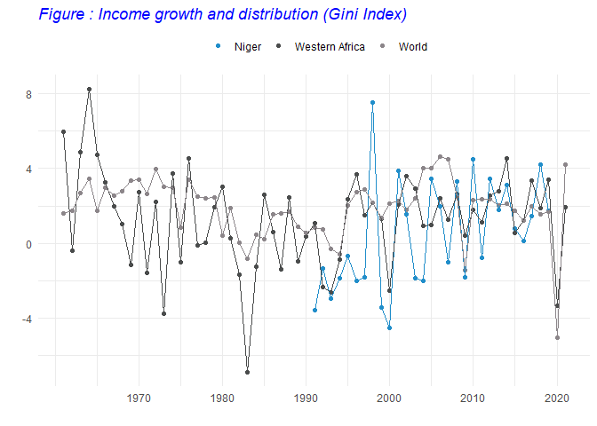

```r
graphics_1 <-ggplot(base_graphics_1) +
 aes(x = end_year, y = value, colour = region_name) +
 geom_point(shape = "circle", size = 1.5) + # pour définir les points
 geom_line() + #Pour ajouter les lignes
 scale_color_manual(values = c(Niger = "#218ECA",
`Western Africa` = "#4A4C4C", World = "#8C868A")) +#les couleurs des courbes
 scale_x_continuous(breaks = seq(1970, max(base_graphics_1$end_year), by = 10)) +  # Définir le pas entre les années à 10
 theme_minimal() + #le thème (le fond)
 theme(legend.position = "top")+ #Position de la legend
 labs( title = "Figure : Income growth and distribution (Gini Index)", x="",y="")+ #titre
 guides(color = guide_legend(override.aes = list(linetype = NA), title = "")) + #Pour éliminer les traits qui sont sur la legend
 theme(plot.title = element_text(colour = "blue",face = "italic"))#Couleur du titre
graphics_1
```

Source : World Bank

# 4 Annual population growth (%)

## 4.1 Creation de la base western_africa

```r
# gender-inequality-index.csv

# Selection des pays
country_western_africa <- c("Benin","Burkina Faso","Cabo Verde","Gambia","Ghana","Guinea","Guinea-Bissau","Mali","Niger","Nigeria","Senegal","Togo","Côte d’Ivoire","Sierra Leone","Mauritania")

# Selection des données et aggregation des données pour avoir les données de west africa
western_africa_2 <- PGA %>%
  filter(region_name %in% country_western_africa)%>%
  group_by(end_year)%>%
  summarise(value=mean(value))

# Création de la variable Region.Name pour west africa
western_africa_2$region_name="Western Africa"

# Changement des position des colonnes
western_africa_2 <- western_africa_2 %>%
  select(region_name,value, end_year)
```

## 4.2 Creation de la base pour le Niger

```r
data_NIG_2 <- PGA%>%
  filter(region_name=="Niger")
```

## 4.3 Aggregation à l’échelle mondiale

```r
# On a aggregé les données pour avoir les données de tout les pays en faisant la somme des values de chaque pays

world <- PGA %>%
  group_by(end_year)%>%
  summarise(value=mean(value))
# Creation de la variable Region.Name

world$region_name="World"

# Changement des position des colonnes
world <- world %>%
  select(region_name,value, end_year)
```

## 4.4 concatenation des trois bases

```r
base_graphics_2 <- bind_rows(western_africa_2,data_NIG_2,world)
base_graphics_2 <-base_graphics_2 %>% select("region_name","value","end_year")
view(base_graphics_2)
```

## 4.5 Representation du graphique de Annual population growth

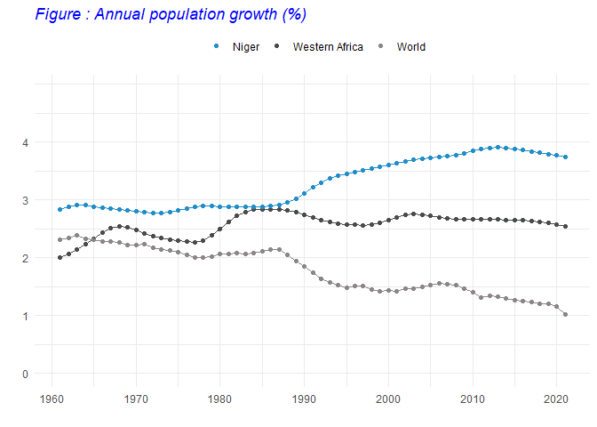

```r
graphics_2 <-ggplot(base_graphics_2) +
 aes(x = end_year, y = value, colour = region_name) +
 geom_point(shape = "circle", size = 1.5) +
 geom_line() +
 scale_color_manual(values = c(Niger = "#218ECA",
`Western Africa` = "#4A4C4C", World = "#8C868A")) +
 scale_x_continuous(breaks = seq(1960, max(base_graphics_2$end_year), by = 10)) +  # Définir le pas entre les années à 10
 scale_y_continuous(limits = c(0, max(base_graphics_2$value) + 1), breaks = seq(0,    max(base_graphics_2$value) + 1, by = 1)) +
  theme_minimal() +
 theme(legend.position = "top")+
 labs( title = "Figure : Annual population growth (%)", x="",y="")+
 guides(color = guide_legend(override.aes = list(linetype = NA), title = "")) +
 theme(plot.title = element_text(colour = "blue",face = "italic"))
graphics_2
```

Source : World Bank

# 5 Gender inequality index

## 5.1 Creation de la base western_africa

```r
# gender-inequality-index.csv

# Selection des pays
country_western_africa <- c("Benin","Burkina Faso","Cabo Verde","Gambia","Ghana","Guinea","Guinea-Bissau","Mali","Niger","Nigeria","Senegal","Togo","Côte d’Ivoire","Sierra Leone","Mauritania")

# Selection des données et aggregation des données pour avoir les données de west africa
western_africa <- GII %>%
  filter(region_name %in% country_western_africa)%>%
  group_by(end_year)%>%
  summarise(value=mean(value))

# Création de la variable Region.Name pour west africa
western_africa$region_name="Western Africa"

# Changement des position des colonnes
western_africa <- western_africa %>%
  select(region_name,value, end_year)
```

## 5.2 Creation de la base pour le Niger

```r
data_NIG <- GII%>%
  filter(region_name=="Niger")
```

## 5.3 Aggregation à l’échelle mondiale

```r
# On a aggregé les données pour avoir les données de tout les pays en faisant la somme des values de chaque pays

world <- GII %>%
  group_by(end_year)%>%
  summarise(value=mean(value))
# Creation de la variable Region.Name

world$region_name="World"

# Changement des position des colonnes
world <- world %>%
  select(region_name,value, end_year)
```

## 5.4 concatenation des trois bases

```r
base_graphics_3 <- bind_rows(western_africa,data_NIG,world)
base_graphics_3 <-base_graphics_3 %>% select("region_name","value","end_year")
view(base_graphics_3)
```

## 5.5 Representation du graphique de Gender inequality index

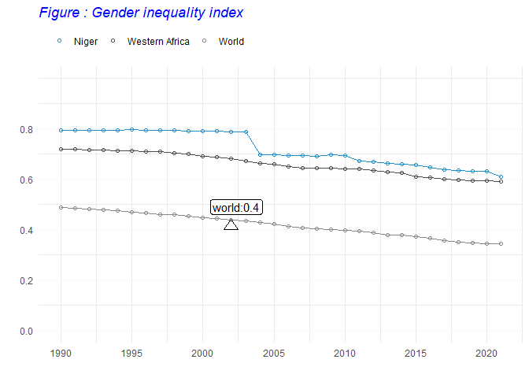

```r
create_dynamic_plot <- function(data) {
  # Préparation du graphique
  p <- ggplot(data, aes(x = end_year, y = value, colour = region_name)) +
    geom_point(shape = 21, na.rm = TRUE) +  # Utilisation du shape 21 pour les points, ignorer les valeurs manquantes
    geom_line(size = 0.5, na.rm = TRUE) +  # Ignorer les valeurs manquantes dans les lignes

    # Définition des couleurs manuelles pour chaque région
    scale_color_manual(values = c("Niger" = "#218ECA",
                                  "Western Africa" = "#4A4C4C",
                                  "World" = "#8C868A"),
                       limits = c("Niger", "Western Africa", "World")) +
    theme_minimal() +
    theme(legend.justification = c(0, 1),
          legend.direction = "horizontal",
          legend.position = "top",
          plot.title = element_text(colour = "blue", face = "italic"),
          panel.grid.major.y = element_line(linetype = "dotted")) +

    # Labels et titres
    labs(title = "Figure : Gender inequality index", x = "", y = "") +
    guides(color = guide_legend(override.aes = list(linetype = NA), title = "")) +

    # Configuration de l'axe X
    scale_x_continuous(breaks = seq(1990, 2020, by = 5),   # Points de rupture tous les 5 ans
                       labels = seq(1990, 2020, by = 5)) + # Étiquettes pour chaque point de rupture

    # Style du titre
    theme(plot.title = element_text(colour = "blue", face = "italic")) +

    # Configuration de l'axe Y
    scale_y_continuous(limits = c(0, max(data$value, na.rm = TRUE) + 0.2),
                       breaks = seq(0, max(data$value, na.rm = TRUE) + 0.2, by = 0.2)) +

    # # Limites explicites pour les axes X et Y pour assurer la cohérence
    # xlim(1990, 2020) +
    # ylim(0, 0.8) +
    # annotate("text", x = 2000, y = 0.55, label = "World")
# Ajout d'annotations pour enrichir visuellement le graphique
  annotate("label",
           x = 2002.36,
           y = 0.49,
           label = "world:0.4",
           fill = "white",
           alpha = 0.8,
           color = "black",
           label.padding = unit(0.2, "lines"),
           label.r = unit(0.2, "lines"),
           label.size = 0.2,
           label.fill = "grey20",
           label.color = "white"
  ) +
  annotate("polygon",
           x = c(2001.45, 2002.47, 2002),
           y = c(0.40, 0.40, 0.44),
           fill = "white",
           alpha = 0.5,
           color = "black"
  )

# Suite du code pour compléter la création du graphique...



  return(p)
}

# Utilisation de la fonction avec vos données
dynamic_plot <- create_dynamic_plot(base_graphics_3)
print(dynamic_plot)
```

Source : UNDP

CONCLUSION

La présente étude revêt une importance capitale, dans la mesure où elle a facilité l’application concrète des concepts théoriques abordés au cours. Par ailleurs, elle a constitué une occasion précieuse d’élargir notre champ de connaissances, spécialement en ce qui concerne la maîtrise du package ggplot2 pour R, un outil essentiel pour la visualisation avancée de données. Cette intégration de la théorie et de la pratique s’avère cruciale pour le développement de compétences analytiques et techniques robustes, essentielles dans notre parcours académique et professionnel.